# Lab 3: Gesture Recognition using Convolutional Neural Networks

### Part (c) “Overfit” to a Small Dataset - 5 pt

One way to sanity check our neural network model and training code is to check whether the model is capable of “overfitting” or “memorizing” a small dataset. A properly constructed CNN with correct training code should be able to memorize the answers to a small number of images quickly.

Construct a small dataset (e.g. just the images that you have collected). Then show that your model and training code is capable of memorizing the labels of this small data set.

With a large batch size (e.g. the entire small dataset) and learning rate that is not too high, You should be able to obtain a 100% training accuracy on that small dataset relatively quickly (within 200 iterations).

```python
# Train Model with small data sets (my own hands) and try to overfit
HandGestureClassifier_check_overfit = HandGestureClassifier()

# For GPU
if torch.cuda.is_available() and use_GPU:
  print("Using GPU")
  HandGestureClassifier_check_overfit.cuda()

train_acc = overfit_testing(HandGestureClassifier_check_overfit, overfit_loader)
```

```
Using GPU
Started Training (to check Overfit)...
Epoch: 1, Training acc: 0.1111111111111111
Epoch: 2, Training acc: 0.2222222222222222
Epoch: 3, Training acc: 0.3333333333333333
Epoch: 4, Training acc: 0.6296296296296297
Epoch: 5, Training acc: 0.8518518518518519
Epoch: 6, Training acc: 0.8888888888888888
Epoch: 7, Training acc: 1.0
Epoch: 8, Training acc: 1.0
Epoch: 9, Training acc: 1.0
Epoch: 10, Training acc: 1.0
Epoch: 11, Training acc: 1.0
Epoch: 12, Training acc: 1.0
Epoch: 13, Training acc: 1.0
Epoch: 14, Training acc: 1.0
Epoch: 15, Training acc: 1.0
Epoch: 16, Training acc: 1.0
Epoch: 17, Training acc: 1.0
Epoch: 18, Training acc: 1.0
Epoch: 19, Training acc: 1.0
Epoch: 20, Training acc: 1.0
Ended Training (to check Overfit)...
```

```python
def overfit_testing(model, loader, batch_size=27, learn_rate = 0.001, num_epochs=20):
    torch.manual_seed(1001)
    criterion = nn.CrossEntropyLoss()
    optimizer = optim.Adam(model.parameters(), lr=learn_rate)

    train_acc = np.zeros(num_epochs)

    # training
    print ("Started Training (to check Overfit)...")
    for epoch in range(num_epochs):
        for images, labels in iter(loader):
            # For GPU
            if torch.cuda.is_available() and use_GPU:
              images = images.cuda()
              labels = labels.cuda()

            optimizer.zero_grad()               # Clean-up
            # Forward pass, backward pass, and optimize
            outputs = model(images)             # forward pass
            loss = criterion(outputs, labels)   # Compute Loss
            loss.backward()                     # backward pass
            optimizer.step()                    # Update each parameter

        # Accuracy
        train_acc[epoch] = get_accuracy(model, loader)
        print("Epoch: {}, Training acc: {}".format(epoch + 1, train_acc[epoch]))

    print ("Ended Training (to check Overfit)...")

    return train_acc
```

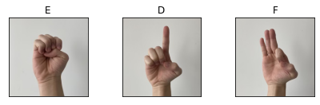

```python
# Loading Data
def overfit_data_loading(batch_size, num_workers):

    # Hand Gesture Image folder location on Google Drive
    hand_img_folder = '/content/drive/My Drive/APS360 Colab Notebooks/Labs/Lab_3b_Gesture_Dataset/'

    # Transform Images to Tensors of pixel size 224 x 224
    transform = transforms.Compose(
            [transforms.ToTensor(),
            transforms.Resize((224, 224))])

    # One folder within hand_img_folder  # 100% Overfit images
    overfit_set = torchvision.datasets.ImageFolder(hand_img_folder + 'Overfitting (My hands)', transform=transform)

    overfit_loader = torch.utils.data.DataLoader(overfit_set, batch_size=batch_size, num_workers=num_workers, shuffle=True)

    return overfit_loader

# batch_size = 3, num_workers = 1
overfit_loader = overfit_data_loading(3, 1)

# Classes from A-I
classes = ['A', 'B', 'C', 'D', 'E', 'F', 'G', 'H', 'I']

# obtain one batch of images from Training
dataiter = iter(overfit_loader)
images, labels = dataiter.next()
images = images.numpy() # convert images to numpy for display

# plot the images in the batch, along with the corresponding labels
fig = plt.figure(figsize=(25, 4))
for idx in np.arange(3):
    ax = fig.add_subplot(2, 20/2, idx+1, xticks=[], yticks=[])
    plt.imshow(np.transpose(images[idx], (1, 2, 0)))
    ax.set_title(classes[labels[idx]])
```

### 3. Hyperparameter Search [10 pt]

### Part (a) - 1 pt

List 3 hyperparameters that you think are most worth tuning. Choose at least one hyperparameter related to the model architecture.

```python
# Batch Size
# Changes the size of information the model error will learn from
# Affects how quickly the model can learn, and how accurate
# Too Small --> Less accurate but trains faster
# Too Large --> Can have generalization error and trains slower

# Number of Epoch
# Changes how many times the entire datasets are iterated
# Affects how quickly and accurately the model learns
# Too Small --> Model may not have learned the dataset properly
# Too Large --> Can take too much time

# Learning Rate
# Changes the gradient decent movement (optimizer),
# Affects how fast the model learn
# Too small --> can get stuck
# Too large --> can have suboptimal solution

# Kernel Size
# The size of the kernel (each filter) can affect how the raw data
# image is processed
```

### Part (b) - 5 pt

Tune the hyperparameters you listed in Part (a), trying as many values as you need to until you feel satisfied that you are getting a good model. Plot the training curve of at least 4 different hyperparameter settings.

```python
def plot_curves(epochs, train_acc, val_acc, name):
  plt.title("Training vs. Validation Accuracy - {}".format(name))
  plt.plot(epochs, train_acc, label="Training")
  plt.plot(epochs, val_acc, label="Validation")
  plt.xlabel("Epochs")
  plt.ylabel("Accuracy")
  plt.legend(loc='best')
  plt.show()

  #plt.title("Validation Curve - {}".format(name))
  #plt.plot(epochs, val_acc)
  #plt.xlabel("Epochs")
  #plt.ylabel("Validation Accuracy")
  #plt.show()
```

```
Using GPU
Started Training...
Training epoch #1 ...
Epoch 1: Train acc: 0.16723783413296778 |Validation acc: 0.1469387755102041
Training epoch #2 ...
Epoch 2: Train acc: 0.2083618917066484 |Validation acc: 0.18571428571428572
Training epoch #3 ...
Epoch 3: Train acc: 0.2604523646333105 |Validation acc: 0.22857142857142856
Training epoch #4 ...
Epoch 4: Train acc: 0.3022618231665524 |Validation acc: 0.27346938775510204
Training epoch #5 ...
Epoch 5: Train acc: 0.3474982864976011 |Validation acc: 0.3306122448979592
Training epoch #6 ...
Epoch 6: Train acc: 0.3721727210418095 |Validation acc: 0.3326530612244898
Training epoch #7 ...
Epoch 7: Train acc: 0.3721727210418095 |Validation acc: 0.373469387755102
Training epoch #8 ...
Epoch 8: Train acc: 0.4002741603838245 |Validation acc: 0.37755102040816324
Training epoch #9 ...
Epoch 9: Train acc: 0.4126113776559287 |Validation acc: 0.38571428571428573
Training epoch #10 ...
Epoch 10: Train acc: 0.4722412611377656 |Validation acc: 0.4306122448979592
Finished Training...
Total time elapsed: 405.78 seconds
```

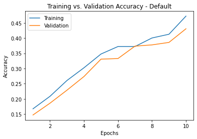

```python
# Train Model with Hyperparameters:
# Learning Rate - 0.001
# Batch Size - 150
# Number of Epoch - 10
# Kernel Size - 1st Convolution layer: 5 & 2nd Convolution layer: 5

name = "Default"

HandGestureClassifier_P1 = HandGestureClassifier(change_kernel_sizes = [5, 5], name = name)

# For GPU
if torch.cuda.is_available() and use_GPU:
  print("Using GPU")
  HandGestureClassifier_P1.cuda()

train_acc, val_acc, epochs = train(HandGestureClassifier_P1, batch_size=150, learning_rate=0.001, num_epochs=10)

plot_curves(epochs, train_acc, val_acc, name)
```

```
Started Training...
Training epoch #1 ...
Epoch 1: Train acc: 0.11240575736806031 |Validation acc: 0.11224489795918367
Training epoch #2 ...
Epoch 2: Train acc: 0.2864976010966415 |Validation acc: 0.27346938775510204
Training epoch #3 ...
Epoch 3: Train acc: 0.42220699108978754 |Validation acc: 0.4061224489795918
Training epoch #4 ...
Epoch 4: Train acc: 0.4578478409869774 |Validation acc: 0.41836734693877553
Training epoch #5 ...
Epoch 5: Train acc: 0.570938999314599 |Validation acc: 0.5571428571428572
Training epoch #6 ...
Epoch 6: Train acc: 0.6079506511309116 |Validation acc: 0.5755102040816327
Training epoch #7 ...
Epoch 7: Train acc: 0.6648389307745031 |Validation acc: 0.5571428571428572
Training epoch #8 ...
Epoch 8: Train acc: 0.7278958190541467 |Validation acc: 0.673469387755102
Training epoch #9 ...
Epoch 9: Train acc: 0.7436600411240576 |Validation acc: 0.6081632653061224
Training epoch #10 ...
Epoch 10: Train acc: 0.7793008910212474 |Validation acc: 0.6795918367346939
Finished Training...
Total time elapsed: 687.28 seconds
```

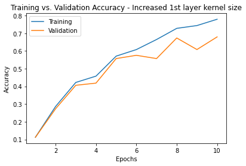

```python
# Here, I tried to increase the kernel size for the 1st layer

# Train Model with Hyperparameters:
# Learning Rate - 0.001
# Batch Size - 150
# Number of Epoch - 10
# Kernel Size - 1st Convolution layer: 10 & 2nd Convolution layer: 5

name = "Increased 1st layer kernel size"

HandGestureClassifier_P2 = HandGestureClassifier(change_kernel_sizes = [10, 5], name = name)

# For GPU
if torch.cuda.is_available() and use_GPU:
  print("Using GPU")
  HandGestureClassifier_P2.cuda()

train_acc, val_acc, epochs = train(HandGestureClassifier_P2, batch_size=150, learning_rate=0.001, num_epochs=10)

plot_curves(epochs, train_acc, val_acc, name)
```

```
Started Training...
Training epoch #1 ...
Epoch 1: Train acc: 0.26662097326936257 |Validation acc: 0.2693877551020408
Training epoch #2 ...
Epoch 2: Train acc: 0.3666895133653187 |Validation acc: 0.3653061224489796
Training epoch #3 ...
Epoch 3: Train acc: 0.564770390678547 |Validation acc: 0.5122448979591837
Training epoch #4 ...
Epoch 4: Train acc: 0.6113776559287183 |Validation acc: 0.5387755102040817
Training epoch #5 ...
Epoch 5: Train acc: 0.6531871144619602 |Validation acc: 0.6040816326530613
Training epoch #6 ...
Epoch 6: Train acc: 0.7073337902673064 |Validation acc: 0.6530612244897959
Training epoch #7 ...
Epoch 7: Train acc: 0.6984235777930089 |Validation acc: 0.6163265306122448
Training epoch #8 ...
Epoch 8: Train acc: 0.7196710075394106 |Validation acc: 0.6530612244897959
Training epoch #9 ...
Epoch 9: Train acc: 0.7580534612748457 |Validation acc: 0.6551020408163265
Training epoch #10 ...
Epoch 10: Train acc: 0.7875257025359835 |Validation acc: 0.7020408163265306
Finished Training...
Total time elapsed: 778.43 seconds
```

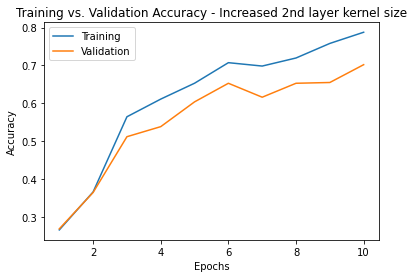

```python
# Here, I will try to increase the kernel size for the 2nd layer.

# Train Model with Hyperparameters:
# Learning Rate - 0.001
# Batch Size - 150
# Number of Epoch - 10
# Kernel Size - 1st Convolution layer: 5 & 2nd Convolution layer: 10

name = "Increased 2nd layer kernel size"

HandGestureClassifier_P3 = HandGestureClassifier(change_kernel_sizes = [5, 10], name = name)

# For GPU
if torch.cuda.is_available() and use_GPU:
  print("Using GPU")
  HandGestureClassifier_P3.cuda()

train_acc, val_acc, epochs = train(HandGestureClassifier_P3, batch_size=150, learning_rate=0.001, num_epochs=10)

plot_curves(epochs, train_acc, val_acc, name)
```

```
Started Training...
Training epoch #1 ...
Epoch 1: Train acc: 0.25154215215901304 |Validation acc: 0.22448979591836735
Training epoch #2 ...
Epoch 2: Train acc: 0.3139136394790953 |Validation acc: 0.30612244897959184
Training epoch #3 ...
Epoch 3: Train acc: 0.49828649760109667 |Validation acc: 0.4959183673469388
Training epoch #4 ...
Epoch 4: Train acc: 0.5846470185058259 |Validation acc: 0.5489795918367347
Training epoch #5 ...
Epoch 5: Train acc: 0.6134338588074023 |Validation acc: 0.5816326530612245
Training epoch #6 ...
Epoch 6: Train acc: 0.6559287183002056 |Validation acc: 0.5571428571428572
Training epoch #7 ...
Epoch 7: Train acc: 0.6901987662782728 |Validation acc: 0.6285714285714286
Training epoch #8 ...
Epoch 8: Train acc: 0.704592186429061 |Validation acc: 0.6204081632653061
Training epoch #9 ...
Epoch 9: Train acc: 0.7052775873886223 |Validation acc: 0.6469387755102041
Training epoch #10 ...
Epoch 10: Train acc: 0.7368060315284441 |Validation acc: 0.6571428571428571
Finished Training...
Total time elapsed: 1050.14 seconds
```

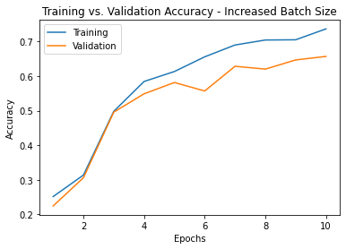

```python
# As it seems increasing the 2nd layer kernel size performed better,
# I will use the same kernel sizes [5, 10] and increase the batch size

# Train Model with Hyperparameters:
# Learning Rate - 0.001
# Batch Size - 250
# Number of Epoch - 10
# Kernel Size - 1st Convolution layer: 5 & 2nd Convolution layer: 10

name = "Increased Batch Size"

HandGestureClassifier_P4 = HandGestureClassifier(change_kernel_sizes = [5, 10], name = name)

# For GPU
if torch.cuda.is_available() and use_GPU:
  print("Using GPU")
  HandGestureClassifier_P4.cuda()

train_acc, val_acc, epochs = train(HandGestureClassifier_P4, batch_size=250, learning_rate=0.001, num_epochs=10)

plot_curves(epochs, train_acc, val_acc, name)
```

```
Started Training...
Training epoch #1 ...
Epoch 1: Train acc: 0.23440712816997944 |Validation acc: 0.23061224489795917
Training epoch #2 ...
Epoch 2: Train acc: 0.3420150788211104 |Validation acc: 0.37142857142857144
Training epoch #3 ...
Epoch 3: Train acc: 0.49074708704592185 |Validation acc: 0.46938775510204084
Training epoch #4 ...
Epoch 4: Train acc: 0.5627141877998629 |Validation acc: 0.5142857142857142
Training epoch #5 ...
Epoch 5: Train acc: 0.6291980808773132 |Validation acc: 0.5897959183673469
Training epoch #6 ...
Epoch 6: Train acc: 0.6620973269362577 |Validation acc: 0.6183673469387755
Training epoch #7 ...
Epoch 7: Train acc: 0.682659355723098 |Validation acc: 0.636734693877551
Training epoch #8 ...
Epoch 8: Train acc: 0.7018505825908157 |Validation acc: 0.6183673469387755
Training epoch #9 ...
Epoch 9: Train acc: 0.7292666209732693 |Validation acc: 0.6346938775510204
Training epoch #10 ...
Epoch 10: Train acc: 0.7368060315284441 |Validation acc: 0.6632653061224489
Finished Training...
Total time elapsed: 887.80 seconds
```

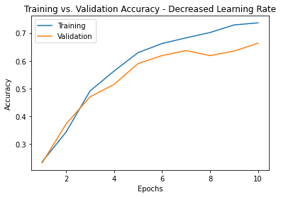

```python
# As it seems increasing batch size made it worse,
# I will use the same kernel sizes [5, 10] and the previous batch size
# and now try to decrease the learning rate

# Train Model with Hyperparameters:
# Learning Rate - 0.0008
# Batch Size - 150
# Number of Epoch - 10
# Kernel Size - 1st Convolution layer: 5 & 2nd Convolution layer: 10

name = "Decreased Learning Rate"

HandGestureClassifier_P5 = HandGestureClassifier(change_kernel_sizes = [5, 10], name = name)

# For GPU
if torch.cuda.is_available() and use_GPU:
  print("Using GPU")
  HandGestureClassifier_P5.cuda()

train_acc, val_acc, epochs = train(HandGestureClassifier_P5, batch_size=150, learning_rate=0.0008, num_epochs=10)

plot_curves(epochs, train_acc, val_acc, name)
```